# Chapter2

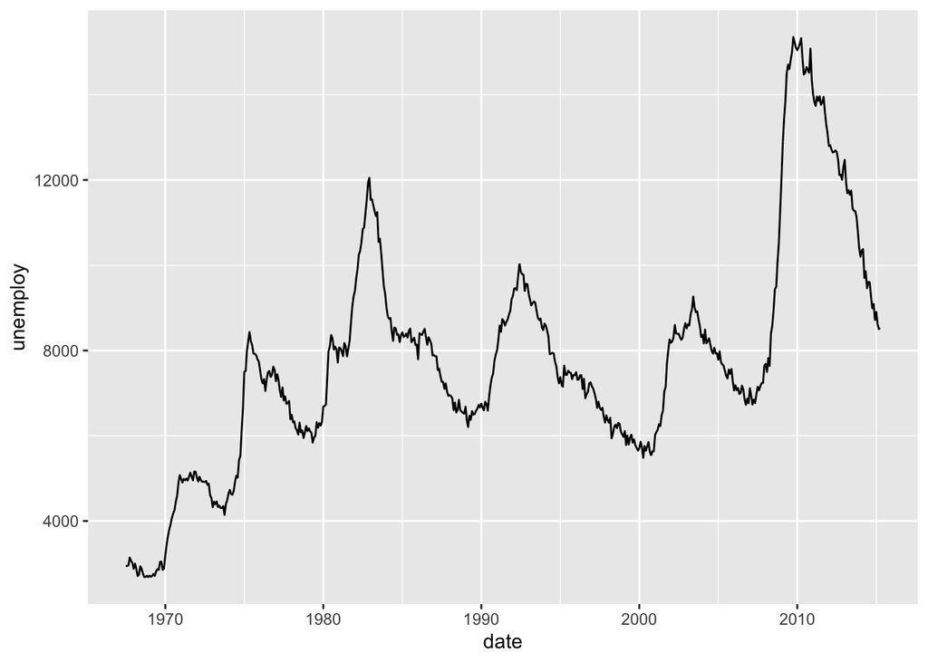

```r
ggplot(economics, aes(date, unemploy)) +
  geom_line()
```

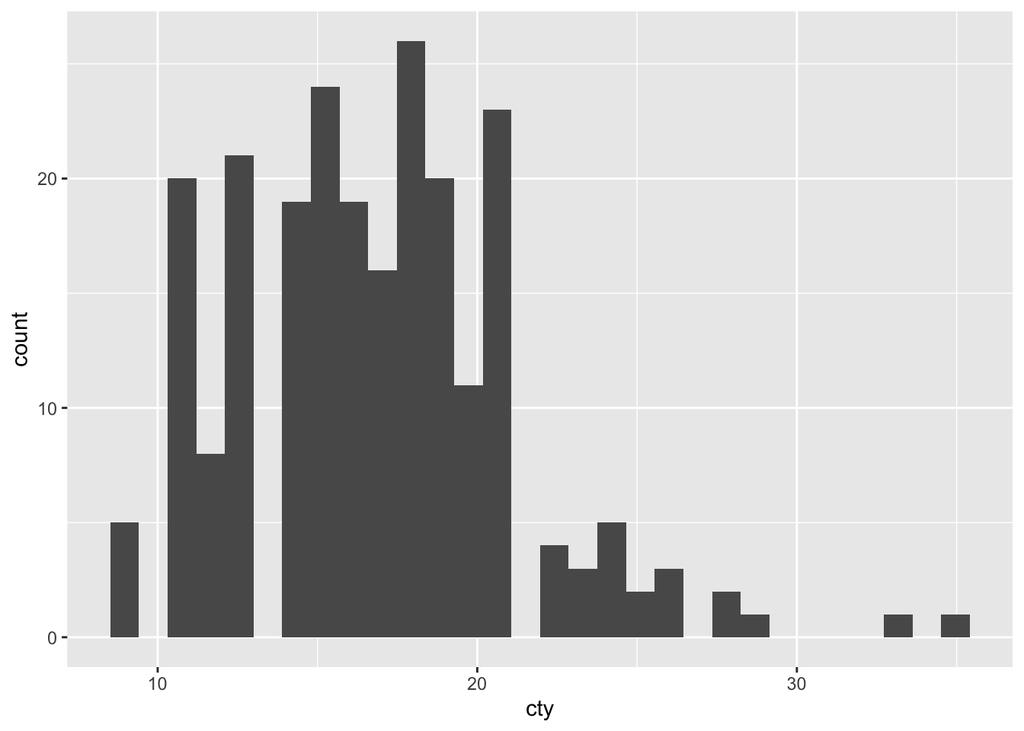

```r
ggplot(mpg, aes(cty)) +
  geom_histogram()
```

Adding attributes in the main plot aes() allows the plot to color/shape/group by value.

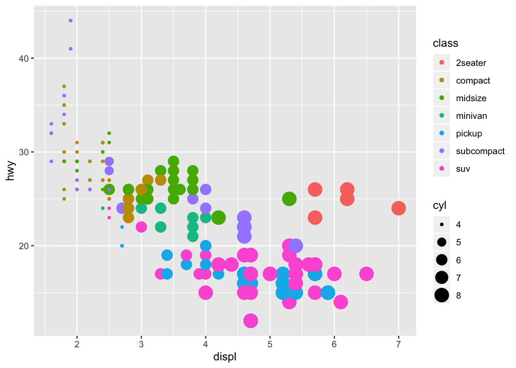

```r
ggplot(mpg, aes(displ, hwy, color=class, size=cyl)) +
  geom_point()
```

Adding attributes in the geom() will alter that individual layer.

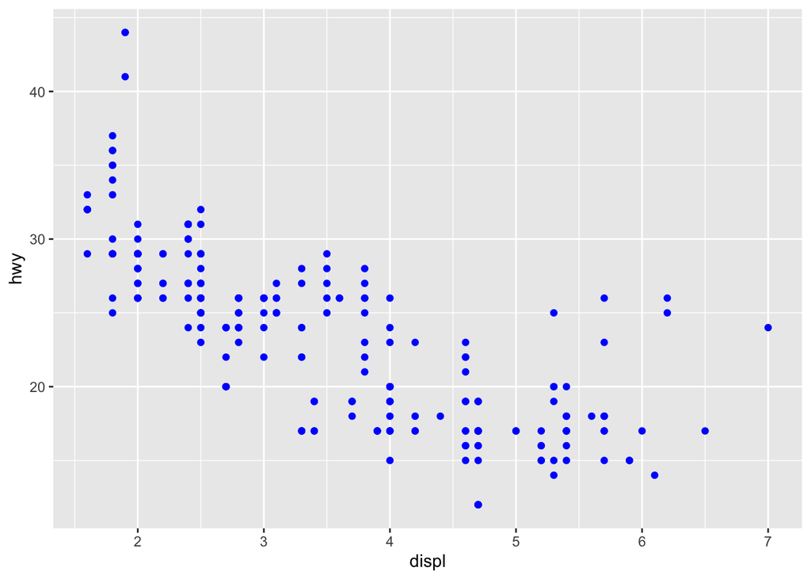

```r
ggplot(mpg, aes(displ, hwy)) +
  geom_point(color="blue")
```

**Exercises**

1. Experiment with the colour, shape and size aesthetics. What happens when you map them to continuous values? What about categorical values? What happens when you use more than one aesthetic in a plot?

```r
str(mpg)
```

```
## Classes 'tbl_df', 'tbl' and 'data.frame':    234 obs. of  11 variables:
##  $ manufacturer: chr  "audi" "audi" "audi" "audi" ...
##  $ model       : chr  "a4" "a4" "a4" "a4" ...
##  $ displ       : num  1.8 1.8 2 2 2.8 2.8 3.1 1.8 1.8 2 ...
##  $ year        : int  1999 1999 2008 2008 1999 1999 2008 1999 1999 2008 ...
##  $ cyl         : int  4 4 4 4 6 6 6 4 4 4 ...
##  $ trans       : chr  "auto(l5)" "manual(m5)" "manual(m6)" "auto(av)" ...
##  $ drv         : chr  "f" "f" "f" "f" ...
##  $ cty         : int  18 21 20 21 16 18 18 18 16 20 ...
##  $ hwy         : int  29 29 31 30 26 26 27 26 25 28 ...
##  $ fl          : chr  "p" "p" "p" "p" ...
##  $ class       : chr  "compact" "compact" "compact" "compact" ...
```

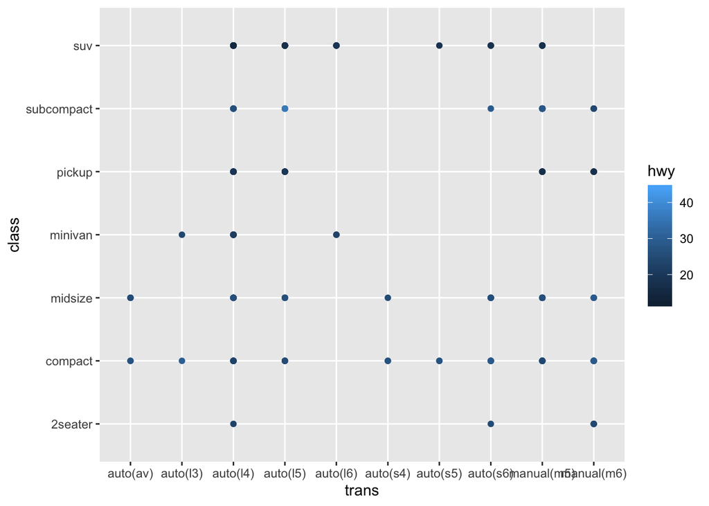

```r
ggplot(mpg, aes(trans, class, color=hwy)) +
  geom_point()
```

When you use color for a continuous variable, you get a gradient with lighter colors representing higher values.

2. What happens if you map a continuous variable to shape? Why? What happens if you map trans to shape? Why?

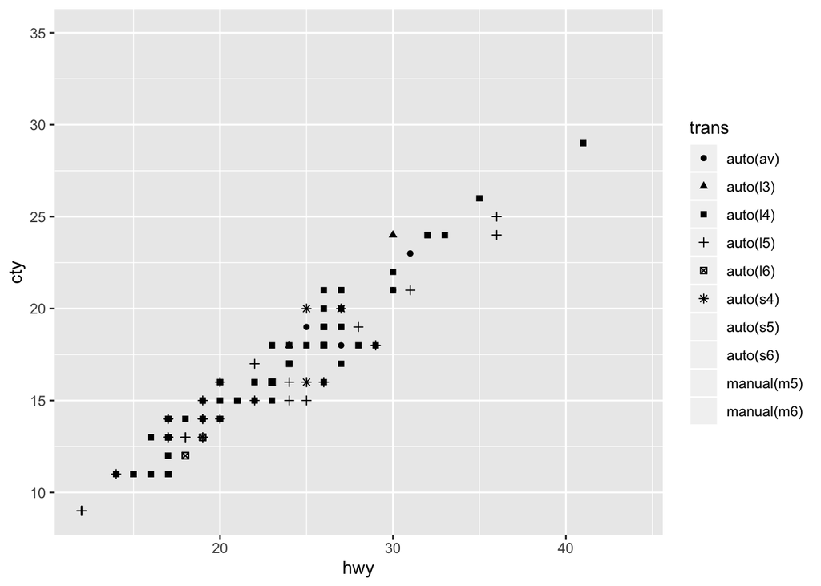

```r
ggplot(mpg, aes(hwy, cty, shape=trans)) +
  geom_point()
```

We run out of shapes and the plot is meaningless.

3. How is drive train related to fuel economy? How is drive train related to engine size and class?

```r
head(mpg)
```

```
## # A tibble: 6 x 11
##   manufacturer model displ  year   cyl trans      drv     cty   hwy fl    class
##   <chr>        <chr> <dbl> <int> <int> <chr>      <chr> <int> <int> <chr> <chr>
## 1 audi         a4      1.8  1999     4 auto(l5)   f        18    29 p     compa…
## 2 audi         a4      1.8  1999     4 manual(m5) f        21    29 p     compa…
## 3 audi         a4      2    2008     4 manual(m6) f        20    31 p     compa…
## 4 audi         a4      2    2008     4 auto(av)   f        21    30 p     compa…
## 5 audi         a4      2.8  1999     6 auto(l5)   f        16    26 p     compa…
## 6 audi         a4      2.8  1999     6 manual(m5) f        18    26 p     compa…
```

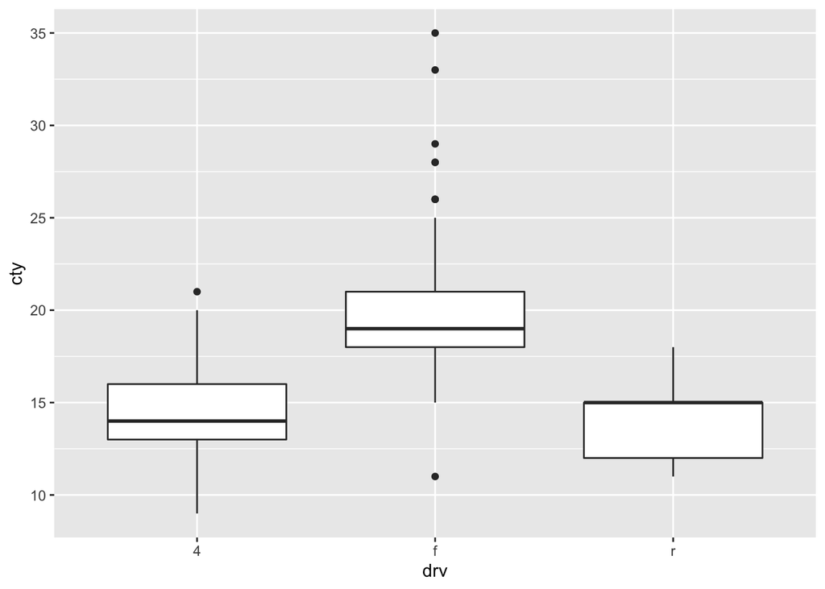

```r
ggplot(mpg, aes(drv, cty)) +
  geom_boxplot()
```

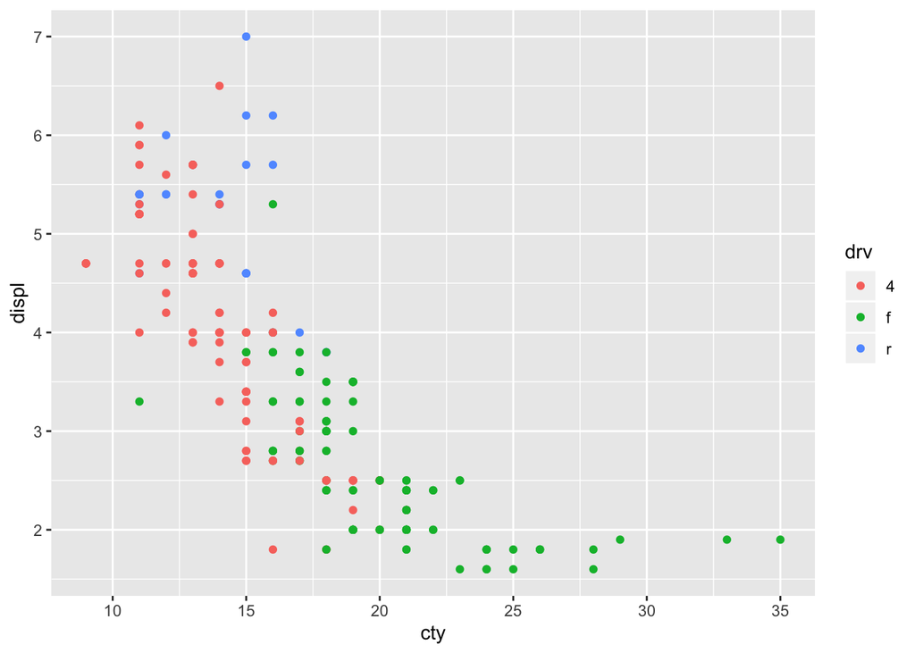

```r
ggplot(mpg, aes(cty, displ, color=drv)) +
  geom_point()
```

You can display categorical data also by facetting. This makes identical plots for each category.

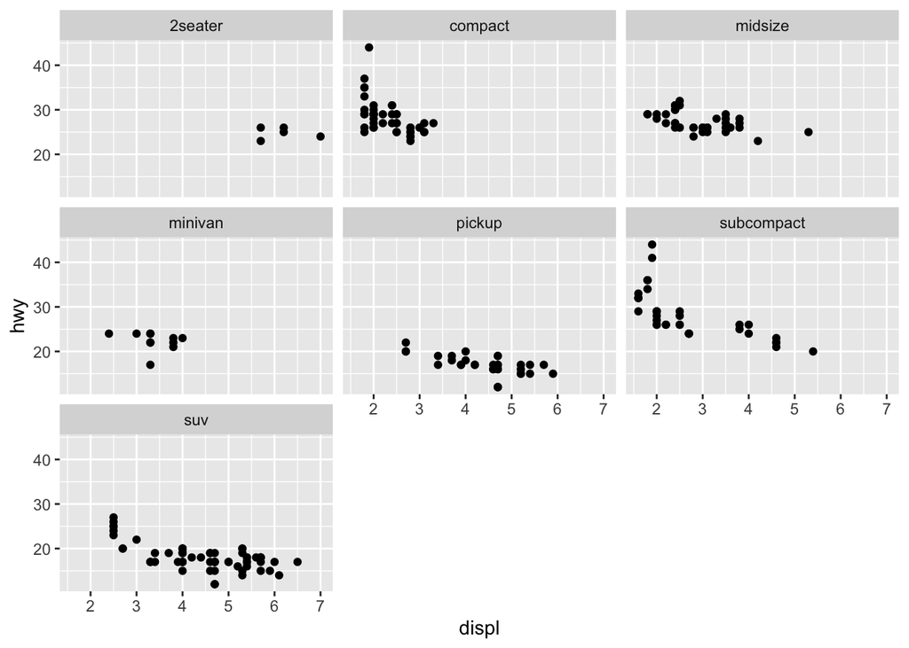

```r
ggplot(mpg, aes(displ, hwy)) +
  geom_point() +
  facet_wrap(~class)
```

**Exercises** 1. What happens if you try to facet by a continuous variable like hwy? What about cyl? What’s the key difference?

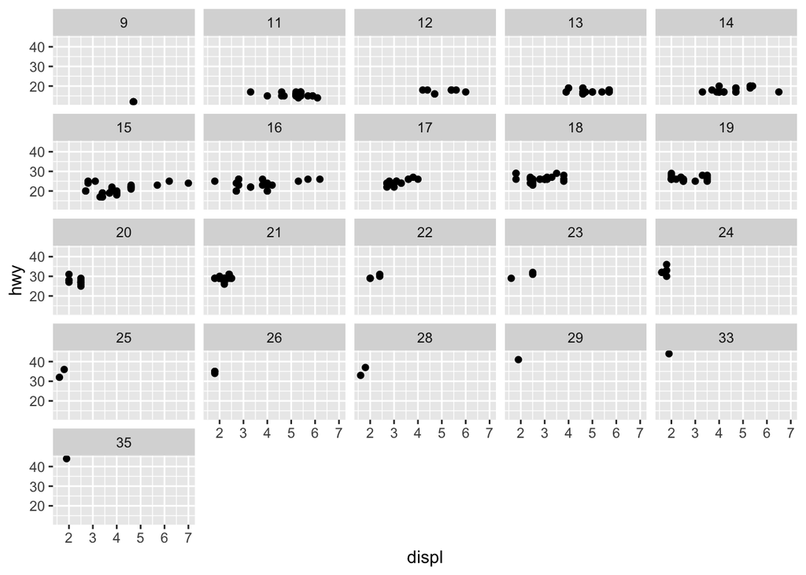

```r
ggplot(mpg, aes(displ, hwy)) +
  geom_point() +
  facet_wrap(~cty)
```

The main difference is that it breaks off a new chart for each value of the continuous variable present in the data.

2. Use facetting to explore the 3-way relationship between fuel economy, engine size, and number of cylinders. How does facetting by number of cylinders change your assessement of the relationship between engine size and fuel economy?

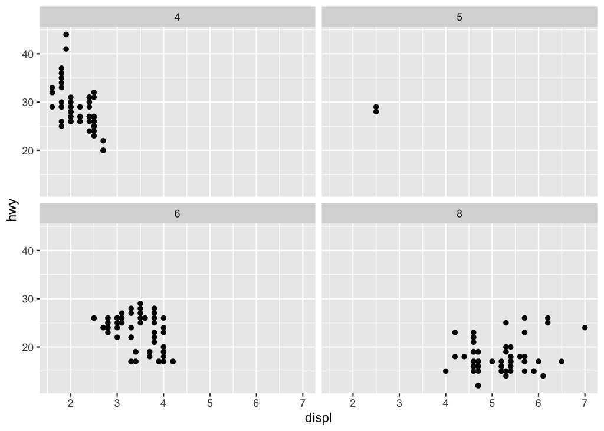

```r
ggplot(mpg, aes(displ, hwy)) +
  geom_point() +
  facet_wrap(~cyl)
```

Doesn’t really change anything.

3. Read the documentation for facet_wrap(). What arguments can you use to control how many rows and columns appear in the output? nrow, ncol
4. What does the scales argument to facet_wrap() do? When might you use it? It allows the scales to be variable between the different plots. It would be useful if you have one variable with far different values than the others. If you allow the scales to be dependent on the data, you can get more detail in each plot.

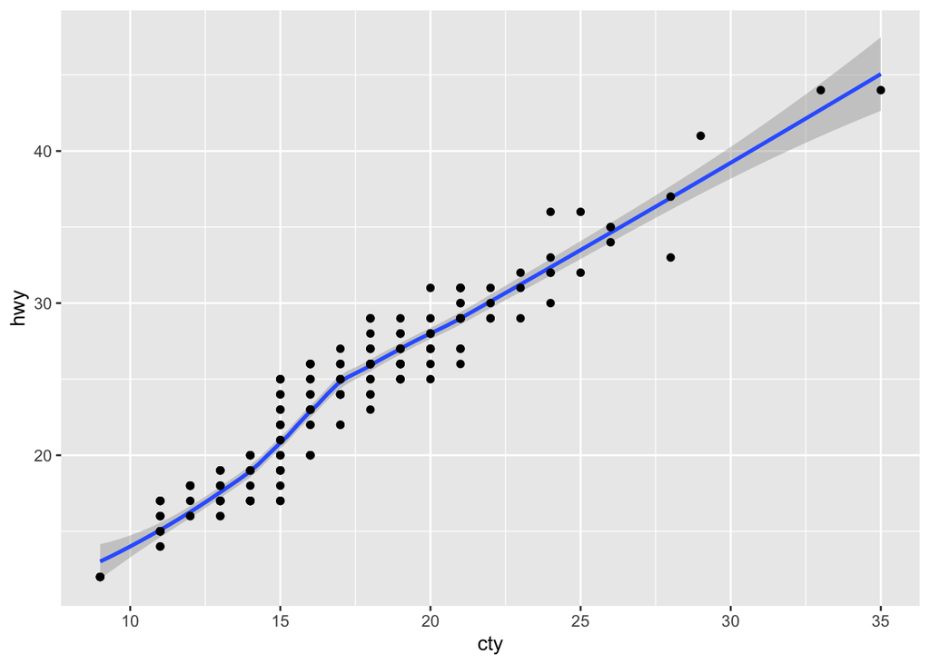

```r
ggplot(mpg, aes(cty, hwy)) +
  geom_smooth() +
  geom_point()
```

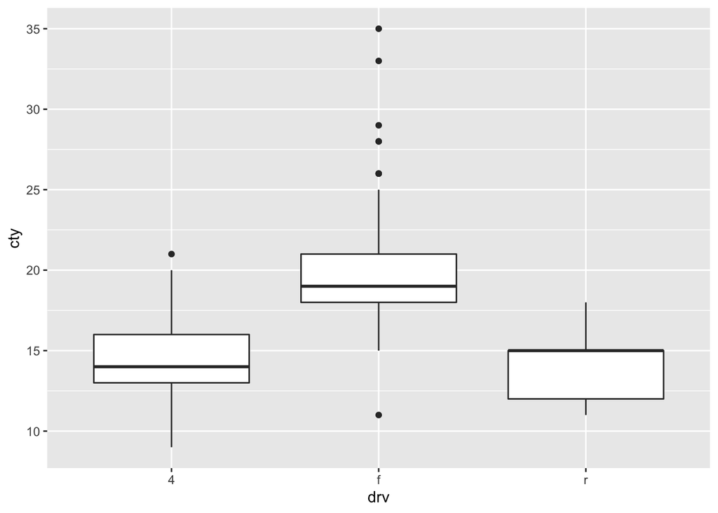

```r
ggplot(mpg, aes(drv, cty)) +
  geom_boxplot()
```

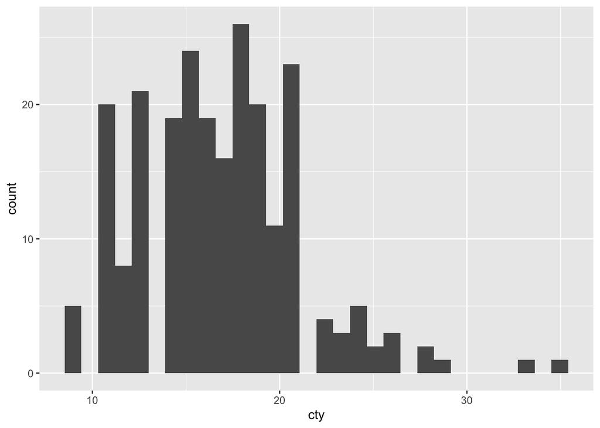

```r
ggplot(mpg, aes(cty)) +
  geom_histogram()
```

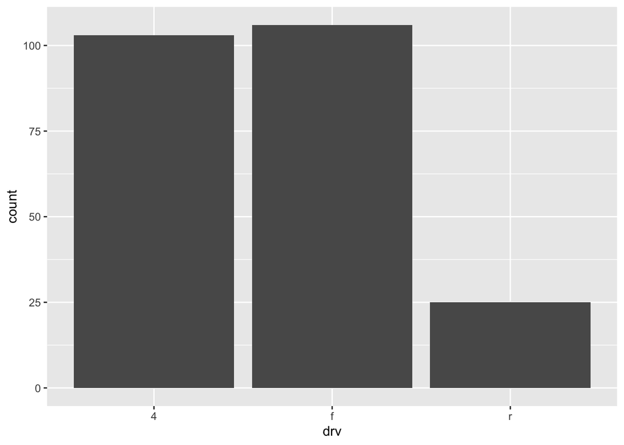

```r
ggplot(mpg, aes(drv)) +
  geom_bar()
```

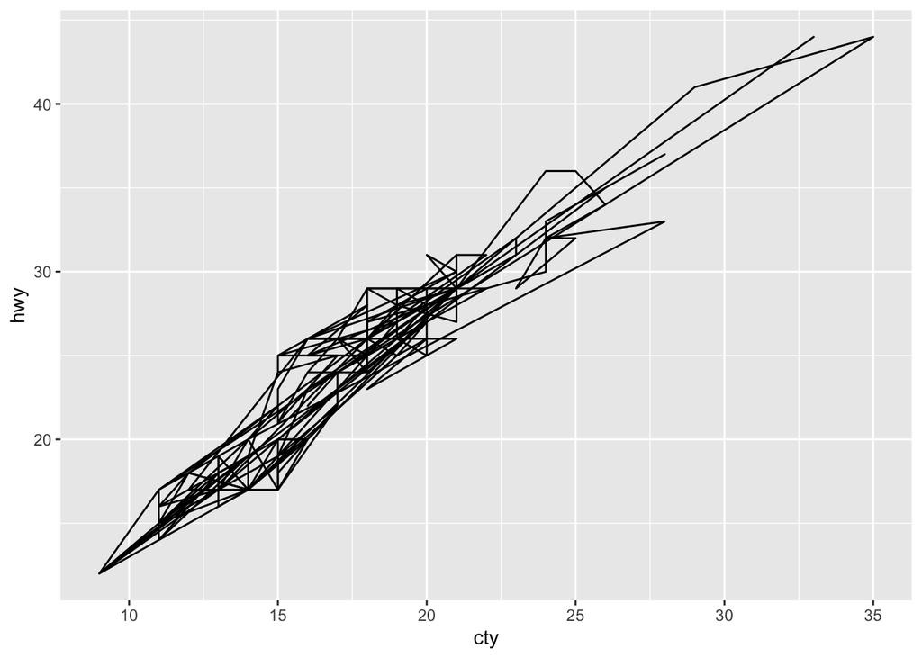

```r
ggplot(mpg, aes(cty, hwy)) +
  geom_path()
```

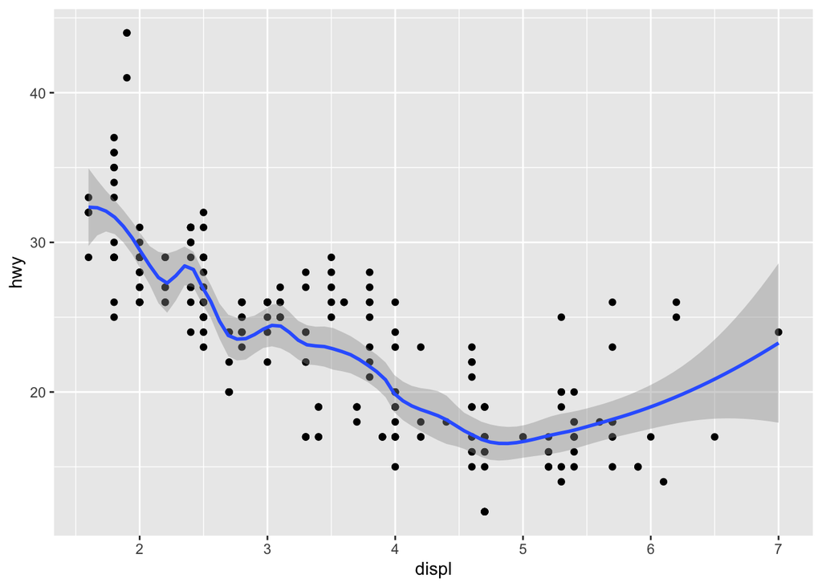

```r
ggplot(mpg, aes(displ, hwy)) +
  geom_point() +
  geom_smooth(method = "auto", span = .3)
```

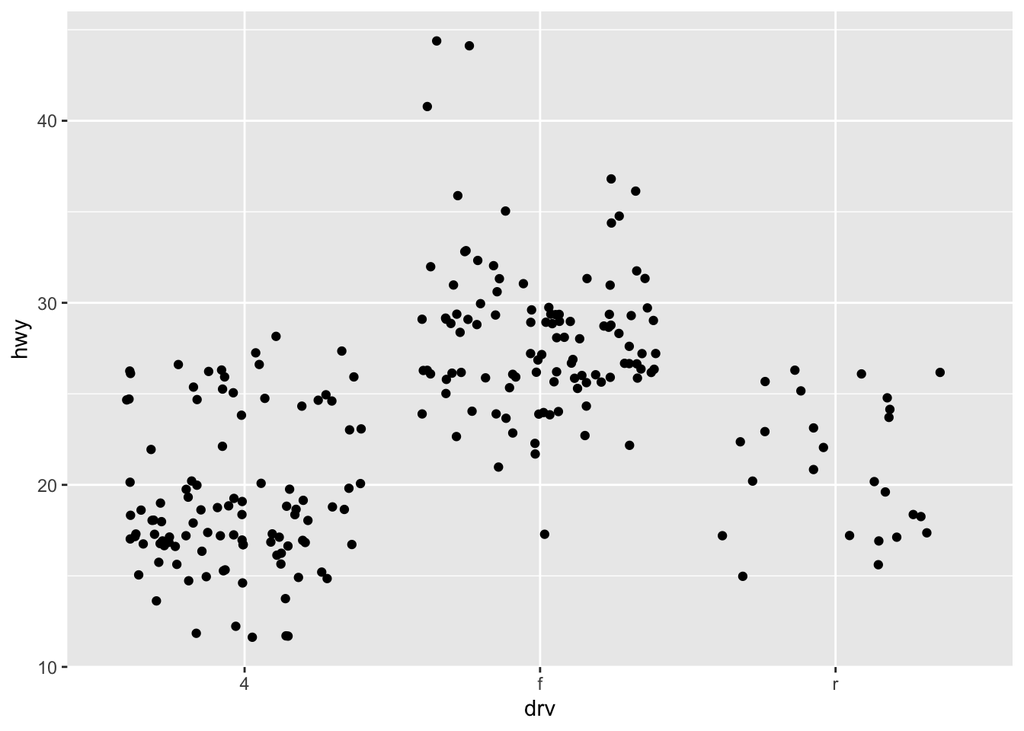

```r
ggplot(mpg, aes(drv, hwy)) +
  geom_jitter()
```

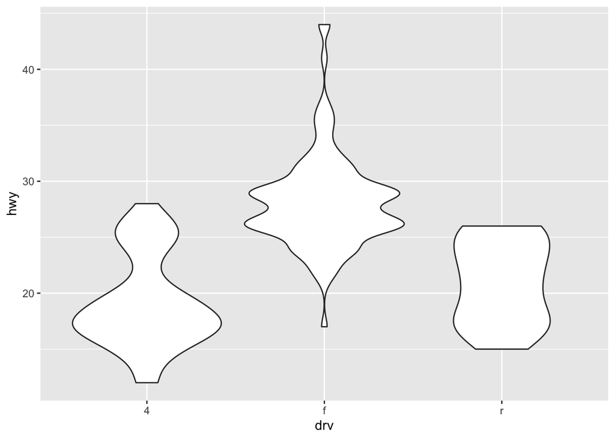

```r
ggplot(mpg, aes(drv, hwy)) +
  geom_violin()
```

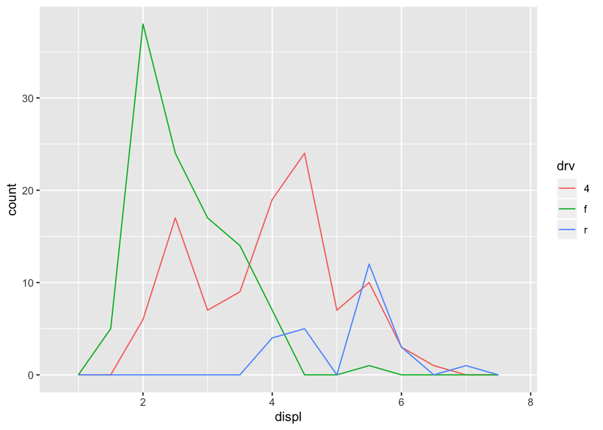

```r
ggplot(mpg, aes(displ, color=drv)) +
  geom_freqpoly(binwidth=0.5)
```

###Time Series

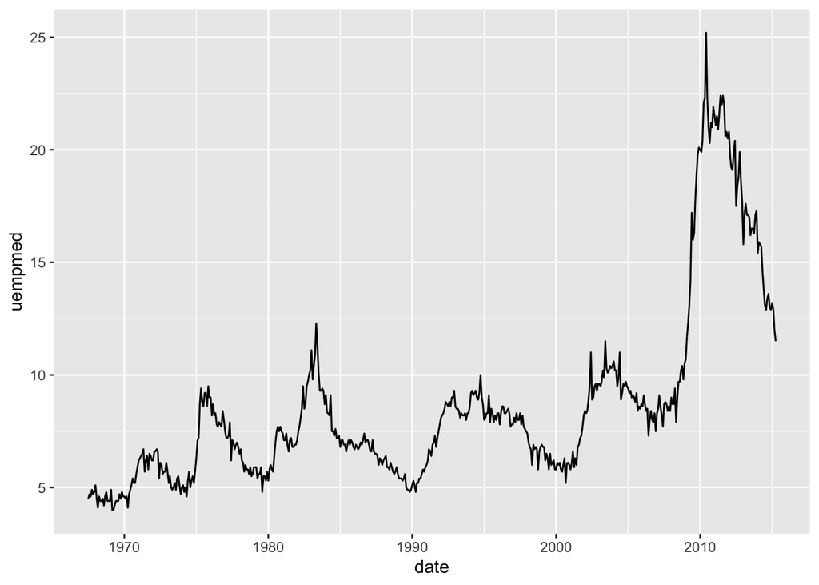

```r
ggplot(economics, aes(date, uempmed)) +
  geom_line()
```

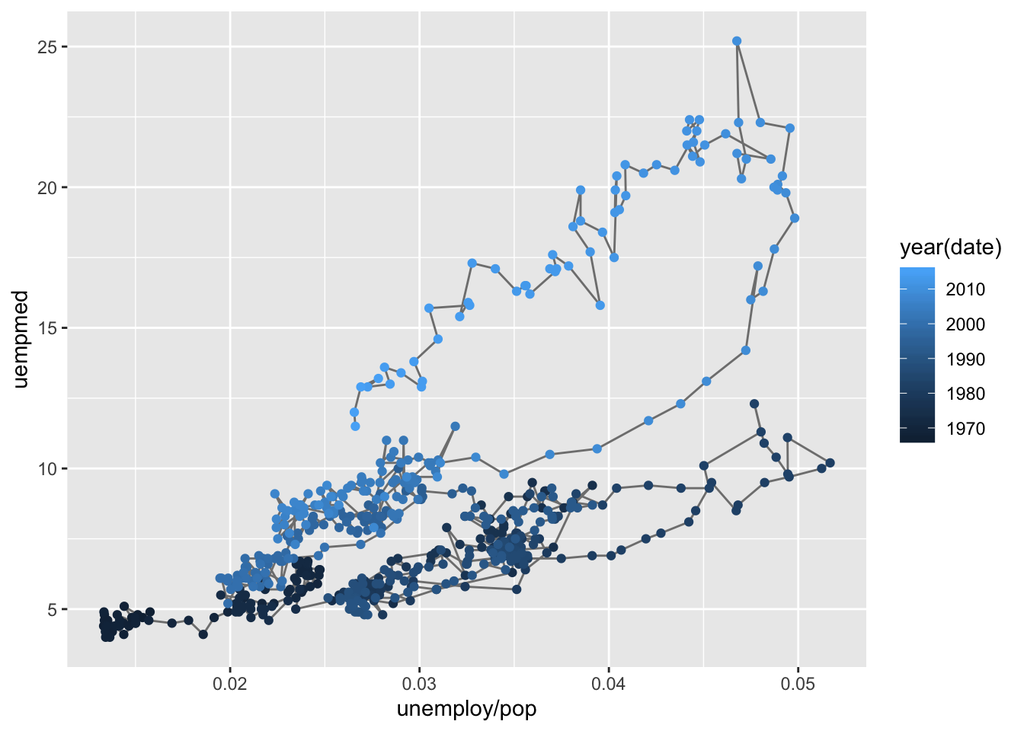

```r
year = function(x) {
  as.POSIXlt(x)$year + 1900
}
ggplot(economics, aes(unemploy / pop, uempmed)) +
  geom_path(colour = "grey50") +
  geom_point(aes(colour = year(date)))
```

**Exercises**

1. What’s the problem with the plot created by ggplot(mpg, aes(cty, hwy)) + geom_point()? Which of the geoms described above is most effective at remedying the problem?

```r
ggplot(mpg, aes(cty, hwy)) +
  geom_point()
```

[output not shown]

Because the values are discrete, there is potential overlap but we cannot see it in this chart.

Here is a better choice.

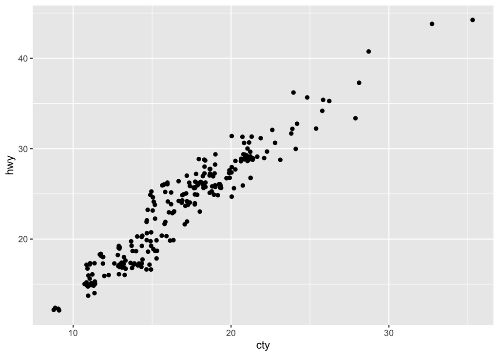

```r
ggplot(mpg, aes(cty, hwy)) +
  geom_jitter()
```

2. One challenge with ggplot(mpg, aes(class, hwy)) + geom_boxplot() is that the ordering of class is alphabetical, which is not terribly useful. How could you change the factor levels to be more informative? Rather than reordering the factor by hand, you can do it automatically based on the data: ggplot(mpg, aes(reorder(class, hwy), hwy)) + geom_boxplot(). What does reorder() do? Read the documentation.
3. Explore the distribution of the carat variable in the diamonds dataset. What binwidth reveals the most interesting patterns?
4. Explore the distribution of the price variable in the diamonds data. How does the distribution vary by cut?
5. You now know (at least) three ways to compare the distributions of subgroups: geom_violin(), geom_freqpoly() and the colour aesthetic, or geom_histogram() and facetting. What are the strengths and weaknesses of each approach? What other approaches could you try?
6. Read the documentation for geom_bar(). What does the weight aesthetic do?
7. Using the techniques already discussed in this chapter, come up with three ways to visualise a 2d categorical distribution. Try them out by visualising the distribution of model and manufacturer, trans and class, and cyl and trans.